# [TD1] Jeux de cartes

Masters Géoprisme et Carthageo

Author

Claude Grasland, Marianne Guérois, Malika Madelin

Published

September 1, 2026

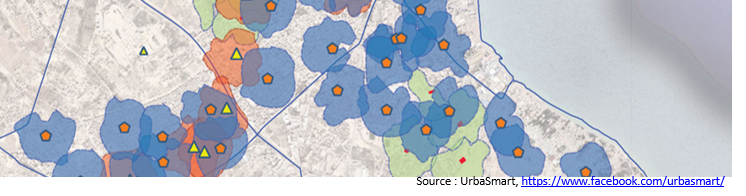

**A propos de ce document**

Ce support de cours “Analyse spatiale, formes et processus” a été créé pour la session 2025-26 du cours d’analyse spatiale des phénomènes sociaux destiné aux étudiant·es de géographie des universités Paris Cité et Paris 1 Panthéon-Sorbonne.

# EXO1 : MESURER LA CONCENTRATION SPATIALE

## Mise en place

On considère un monde composé de 48 positions spatiales, chacune d’entre elles étant occupée par une carte à jouer d’un jeu de 52 cartes dont on a retiré les rois. Cinq tirages différents ont été effectués au hasard.

On choisit l’un des cinq jeux comme monde et on le visualise :

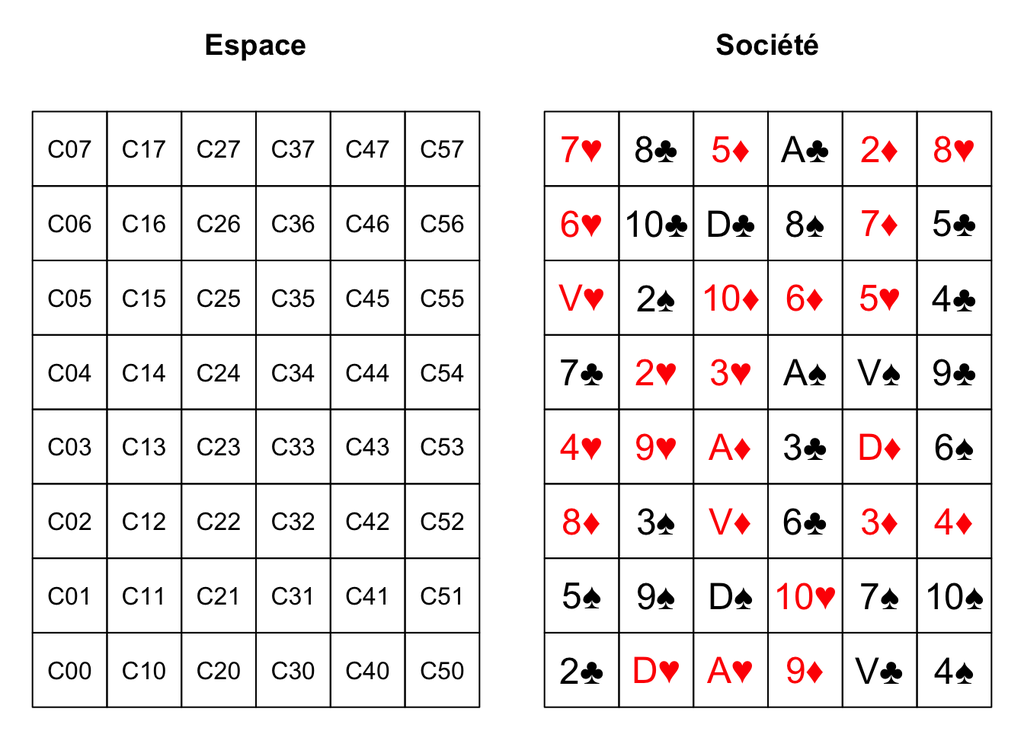

Nous avons quatre familles d’individus correspondants à Pique, Coeur, Carreau et Trèfle. Proposez une méthode pour répondre à la question

> **Laquelle de ces familles est la plus concentrée spatialement ? La plus dispersée ?**

## Solution 1 : Point moyen, distance-type et ellipse de dispersion

Vous avez sans doute appris en licence quelques bases de **statistique spatiale**. Celle-ci propose notamment de calculer pour chaque distribution de points de coordonnées $(X_i,Y_i)$ le centre de gravité $G(X_g,Y_g)$ :

$X_g = \frac{\Sigma_{i=1}^n{X_i}}{n}$

$Y_g = \frac{\Sigma_{i=1}^n{X_i}}{n}$

On peut ensuite calculer l’écart-type de $X$ et $Y$ :

$\sigma_X = \frac{\Sigma_{i=1}^n{(X_i-X_g)^2}}{n-1}$

$\sigma_Y = \frac{\Sigma_{i=1}^n{(Y_i-Y_g)^2}}{n-1}$

Et finalement en déduire la distance-type $\sigma_{X,Y}$ de chaque point au centre de gravité par la formule :

$\sigma_{X,Y} = \sqrt{\sigma_X^2+\sigma_Y^2}$

Passons au calcul dans R. Il suffit pour cela d’utiliser la fonction moyenne (*mean*) et la fonction écart-type (*sd*) en les combinant avec la fonction *tapply()* qui permet d’effectuer le calcul par sous-tableaux en fonction de la variable décrivant la famille des cartes.

|  | Xg | Yg | X_ect | Y_ect | D_type |
| --- | --- | --- | --- | --- | --- |
| ♠ | 3.33 | 2.92 | 1.80 | 1.93 | 2.64 |
| ♣ | 3.17 | 4.67 | 1.87 | 2.48 | 3.11 |
| ♥ | 2.08 | 4.25 | 1.68 | 2.45 | 2.97 |
| ♦ | 3.42 | 4.17 | 1.38 | 2.27 | 2.66 |

On déduit facilement de ce tableau la distribution la plus dispersée et la moins dispersée.

On peut ensuite visualiser le résultat à l’aide d’**ellipses de dispersions** qui permettent de repérer à la fois le centre de gravité et les zones de localisation les plus probables des points. Sans entrer dans les détails mathématiques, on peut voir ci-dessous comment les ellipses de dispersion correspondant aux intervalles de confiance 25%, 50% et 75% sont plus ou moins étendues.

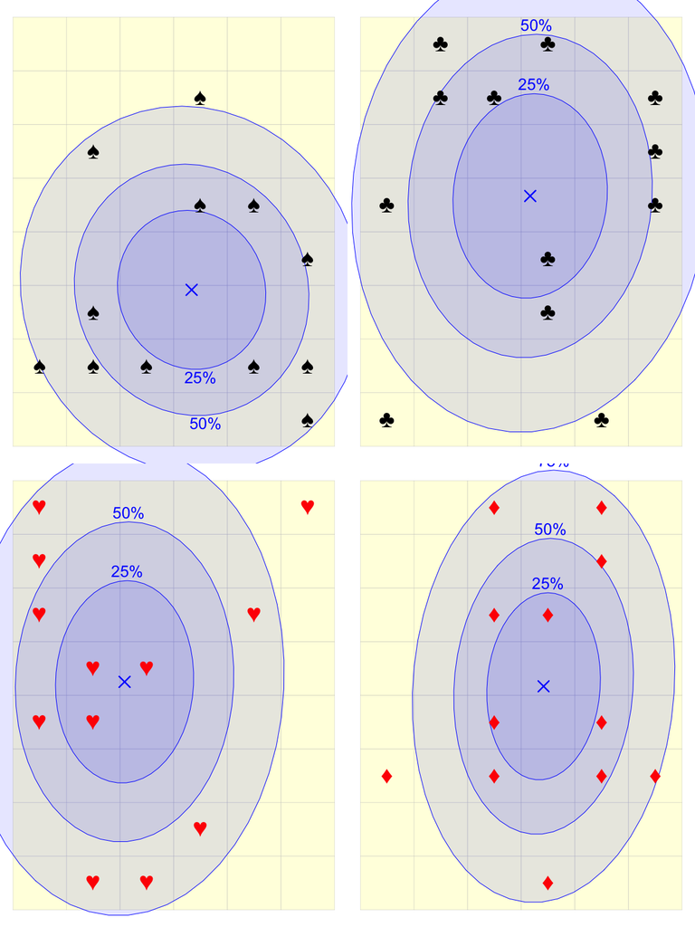

**Discussion**

La solution précédente est relativement complexe puisqu’elle fait appel à des notions statistiques pas forcément connues. Mais surtout elle comporte des hypothèses implicites concernant la distribution spatiale et l’éloignement des points. Elle se place en effet dans un **espace euclidien continu** et suppose que les distributions de X et de Y sont de nature **gaussienne**. Or rien n’indique que ces deux hypothèses soient valides !

## Solution 2 : Distances et métriques

Supposons maintenant que l’on ne puisse pas se déplacer dans n’importe quelle direction mais seulement horizontalement et verticalement en passant d’un carreau au carreau voisin. On se trouve alors dans un espace ayant une géométrie particulière telle que la distance entre deux points est une **distance rectilinéaire** aussi appelée **distance de Manhattan** ou **distance *city-block*** :

$D_{ij} = |X_i-X_j| + |Y_i-Y_j|$

Examinons la distribution des individus de la famille “Pique”♠ :

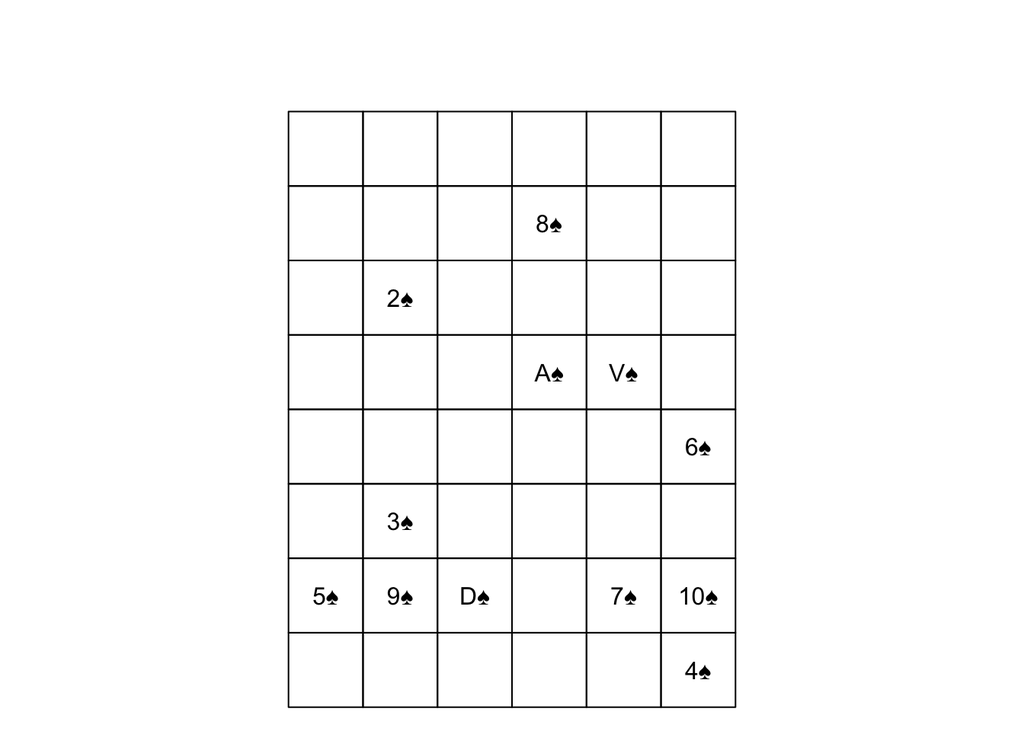

On construit un repère orthonormé où le point situé en bas à gauche correspond à l’origine $(0,0)$ et où chaque carreau a un côté de longueur 1. On en déduit les **coordonnées** de chacune des cartes de la famille en supposant qu’elles sont placées au centre de leur carreau :

|  | cards | X | Y |
| --- | --- | --- | --- |
| 3 | 4♠ | 5.5 | 0.5 |
| 4 | 5♠ | 0.5 | 1.5 |
| 8 | 9♠ | 1.5 | 1.5 |
| 11 | D♠ | 2.5 | 1.5 |
| 6 | 7♠ | 4.5 | 1.5 |
| 9 | 10♠ | 5.5 | 1.5 |
| 2 | 3♠ | 1.5 | 2.5 |
| 5 | 6♠ | 5.5 | 3.5 |
| 13 | A♠ | 3.5 | 4.5 |
| 10 | V♠ | 4.5 | 4.5 |
| 1 | 2♠ | 1.5 | 5.5 |
| 7 | 8♠ | 3.5 | 6.5 |

On en déduit la **matrice de distance** suivante :

```
    4♠ 5♠ 9♠ D♠ 7♠ 10♠ 3♠ 6♠ A♠ V♠ 2♠ 8♠
4♠  NA  6  5  4  2   1  6  3  6  5  9  8
5♠   6 NA  1  2  4   5  2  7  6  7  5  8
9♠   5  1 NA  1  3   4  1  6  5  6  4  7
D♠   4  2  1 NA  2   3  2  5  4  5  5  6
7♠   2  4  3  2 NA   1  4  3  4  3  7  6
10♠  1  5  4  3  1  NA  5  2  5  4  8  7
3♠   6  2  1  2  4   5 NA  5  4  5  3  6
6♠   3  7  6  5  3   2  5 NA  3  2  6  5
A♠   6  6  5  4  4   5  4  3 NA  1  3  2
V♠   5  7  6  5  3   4  5  2  1 NA  4  3
2♠   9  5  4  5  7   8  3  6  3  4 NA  3
8♠   8  8  7  6  6   7  6  5  2  3  3 NA
```

Il est alors facile de calculer les paramètres de la **distribution des distances entre deux individus** différents de la famille pique. Il suffit de retirer du calcul la diagonale et de procéder à un résumé statistique des $12x11 = 132$ distances entre les paires d’individus composant cette famille.

```
   Min. 1st Qu.  Median    Mean 3rd Qu.    Max.    NA's
  1.000   3.000   4.000   4.318   6.000   9.000      12
```

On peut également déterminer combien de paires d’individus sont **voisins** (situées dans des cases voisines).

```
FALSE  TRUE
  120    12
```

Et plus généralement on peut calculer la forme de la distribution des distances entre paires d’individus afin de déterminer la **distance modale** qui est le cas le plus fréquent.

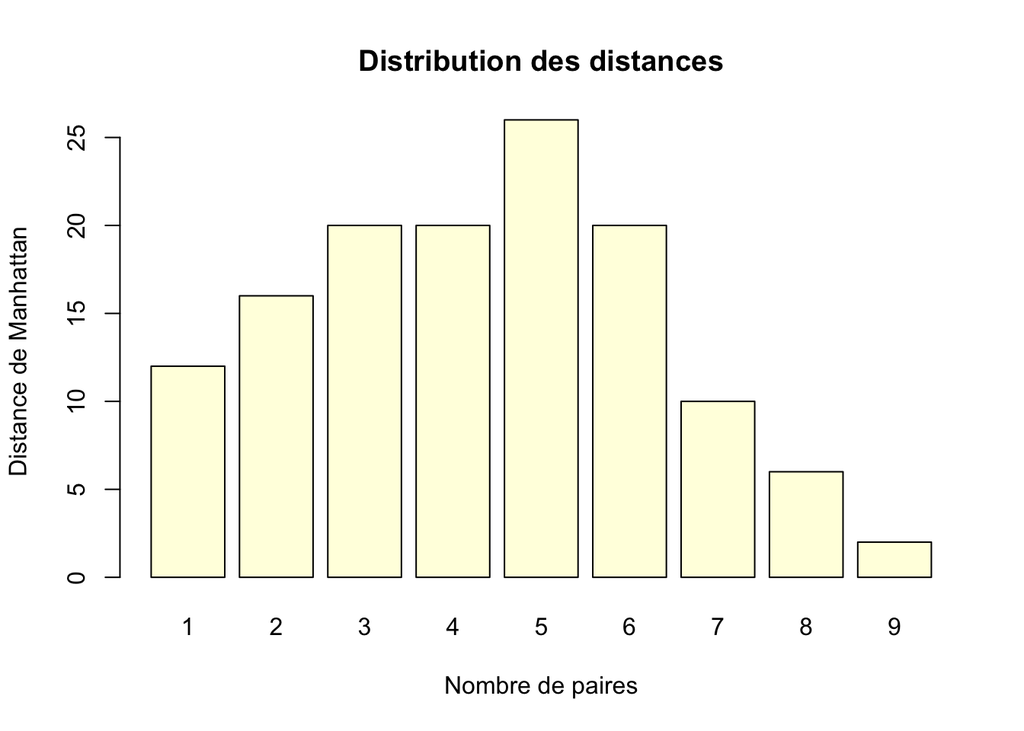

**Discussion**

Nous avons désormais une famille de solutions plus simples et plus concrètes pour mesurer la concentration. Mais quelle solution retenir pour comparer entre elles les familles : distance moyenne, distance médiane, distance modale, distance minimale, distance maximale… Comme le montre bien la figure précédente, la distribution des distances entre les paires d’individus peut faire l’objet de résumés très différents et il n’existe pas de solution unique. On peut en effet imaginer le cas de **distributions concentrées localement et dispersées globalement**.

Considérez l’exemple suivant :

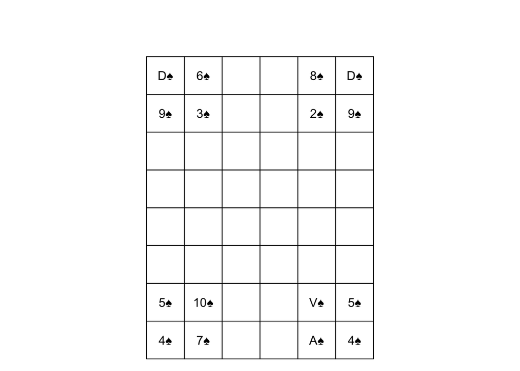

```
   Min. 1st Qu.  Median    Mean 3rd Qu.    Max.    NA's
  1.000   4.000   6.000   5.798   8.250  12.000      16
```

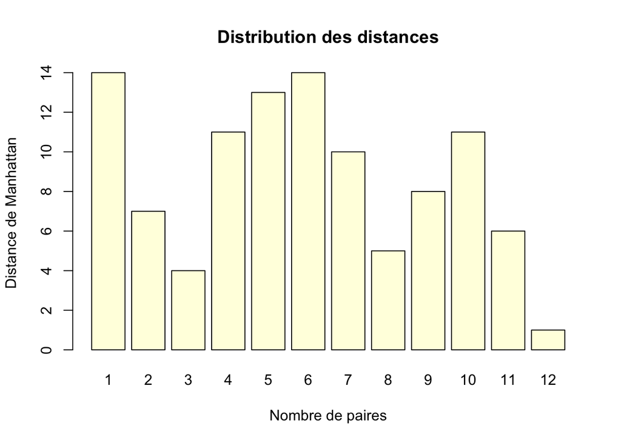

**Commentaire :**

## Solution 3 : Graphe et composantes connexes

Une troisième solution (qui devrait rappeler les règles du jeu de go à ceux et celles qui le connaissent) consiste à déterminer le degré de fragmentation de chaque famille en **composantes connexes**. On considère désormais que deux individus d’une même famille sont reliés s’il existe un chemin les reliant qui ne passe que par des membres de la même famille. On va donc définir un **graphe de voisinage** entre les cellules et considérer que la relation est possible si des membres de la même famille se trouvent de part et d’autre.

Ceci revient à déterminer toutes les paires contiguës $(C_{ij}=1)$ puis à vérifier si elles relient des individus similaires $(S_{ij}=1)$ pour déterminer si la relation entre eux est possible $(R_{ij}=1)$. On trouve 44 paires orientées soit 22 paires symétriques vérifiant les conditions.

| i | j | Cij | ii | jj | Sij | Rij |
| --- | --- | --- | --- | --- | --- | --- |
| 10♠ | 4♠ | 1 | ♠ | ♠ | 1 | 1 |
| 10♠ | 7♠ | 1 | ♠ | ♠ | 1 | 1 |
| 3♠ | 9♠ | 1 | ♠ | ♠ | 1 | 1 |
| 4♠ | 10♠ | 1 | ♠ | ♠ | 1 | 1 |
| 5♠ | 9♠ | 1 | ♠ | ♠ | 1 | 1 |
| 7♠ | 10♠ | 1 | ♠ | ♠ | 1 | 1 |
| 9♠ | 3♠ | 1 | ♠ | ♠ | 1 | 1 |
| 9♠ | 5♠ | 1 | ♠ | ♠ | 1 | 1 |
| 9♠ | D♠ | 1 | ♠ | ♠ | 1 | 1 |
| A♠ | V♠ | 1 | ♠ | ♠ | 1 | 1 |
| D♠ | 9♠ | 1 | ♠ | ♠ | 1 | 1 |
| V♠ | A♠ | 1 | ♠ | ♠ | 1 | 1 |
| 10♣ | 8♣ | 1 | ♣ | ♣ | 1 | 1 |
| 10♣ | D♣ | 1 | ♣ | ♣ | 1 | 1 |
| 3♣ | 6♣ | 1 | ♣ | ♣ | 1 | 1 |
| 4♣ | 5♣ | 1 | ♣ | ♣ | 1 | 1 |
| 4♣ | 9♣ | 1 | ♣ | ♣ | 1 | 1 |
| 5♣ | 4♣ | 1 | ♣ | ♣ | 1 | 1 |
| 6♣ | 3♣ | 1 | ♣ | ♣ | 1 | 1 |
| 8♣ | 10♣ | 1 | ♣ | ♣ | 1 | 1 |
| 9♣ | 4♣ | 1 | ♣ | ♣ | 1 | 1 |
| D♣ | 10♣ | 1 | ♣ | ♣ | 1 | 1 |
| 2♥ | 3♥ | 1 | ♥ | ♥ | 1 | 1 |
| 2♥ | 9♥ | 1 | ♥ | ♥ | 1 | 1 |
| 3♥ | 2♥ | 1 | ♥ | ♥ | 1 | 1 |
| 4♥ | 9♥ | 1 | ♥ | ♥ | 1 | 1 |
| 6♥ | 7♥ | 1 | ♥ | ♥ | 1 | 1 |
| 6♥ | V♥ | 1 | ♥ | ♥ | 1 | 1 |
| 7♥ | 6♥ | 1 | ♥ | ♥ | 1 | 1 |
| 9♥ | 2♥ | 1 | ♥ | ♥ | 1 | 1 |
| 9♥ | 4♥ | 1 | ♥ | ♥ | 1 | 1 |
| A♥ | D♥ | 1 | ♥ | ♥ | 1 | 1 |
| D♥ | A♥ | 1 | ♥ | ♥ | 1 | 1 |
| V♥ | 6♥ | 1 | ♥ | ♥ | 1 | 1 |
| 10♦ | 6♦ | 1 | ♦ | ♦ | 1 | 1 |
| 2♦ | 7♦ | 1 | ♦ | ♦ | 1 | 1 |
| 3♦ | 4♦ | 1 | ♦ | ♦ | 1 | 1 |
| 3♦ | D♦ | 1 | ♦ | ♦ | 1 | 1 |
| 4♦ | 3♦ | 1 | ♦ | ♦ | 1 | 1 |
| 6♦ | 10♦ | 1 | ♦ | ♦ | 1 | 1 |
| 7♦ | 2♦ | 1 | ♦ | ♦ | 1 | 1 |
| A♦ | V♦ | 1 | ♦ | ♦ | 1 | 1 |
| D♦ | 3♦ | 1 | ♦ | ♦ | 1 | 1 |
| V♦ | A♦ | 1 | ♦ | ♦ | 1 | 1 |

On peut alors déterminer la famille qui dispose du plus grand nombre de relations de voisinage avec des membres de sa famille :

```
 ♠  ♣  ♥  ♦
12 10 12 10
```

On peut visualiser ce résultat sous la forme d’un graphe :

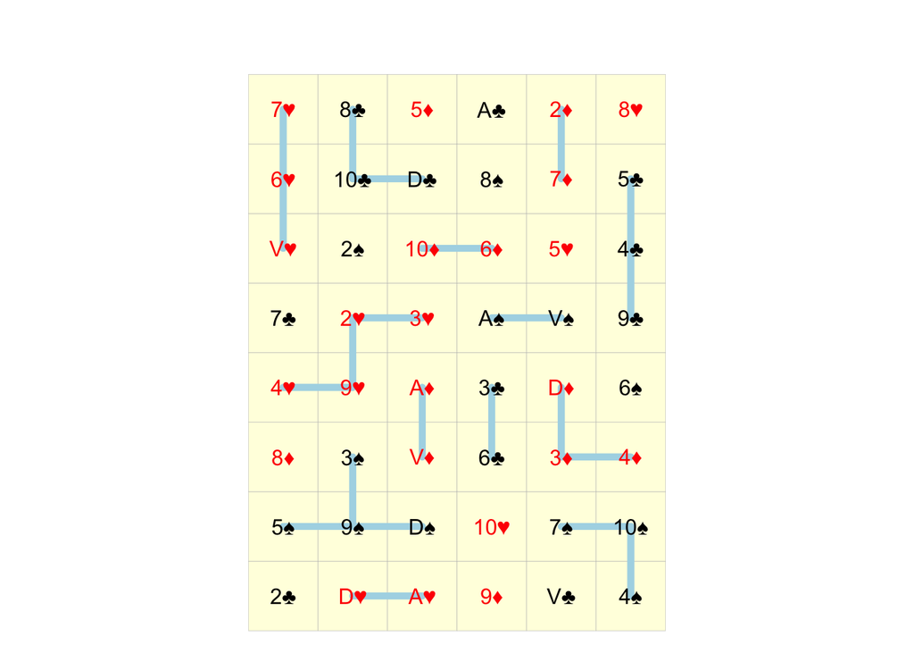

# EXO2 : DYNAMIQUES DE SÉGRÉGATION ET D’OPINION

## Mise en place

Une quarantaine d’étudiant·es entrent dans une salle de cours comportant 6 rangées de 8 chaises. Sans dire un mot, les enseignant·es leur remettent silencieusement une carte à jouer tirée d’un jeu de 52 cartes d’où les rois ont été retirés et leur demandent de s’installer. Les enseignant·es procèdent à l’appel en suivant l’ordre des rangées et chaque étudiant·e indique la carte à jour qui lui a été attribuée, tandis que l’enseignant·e lui indique sa position spatiale :

- **Étudiant·e** : Je suis Camille Dupont et ma carte est le 8 de Pique.
- **Enseignant·e** : Vous occupez la place C36.

Après avoir saisi la position de tous les étudiant·es, les enseignants effectuent quelques manipulations sur leur ordinateur et affichent la carte suivante à l’écran. On notera qu’il existe un certain nombre de places vides qui vont jouer un rôle important dans les modèles de ségrégation et de diffusion d’opinion.

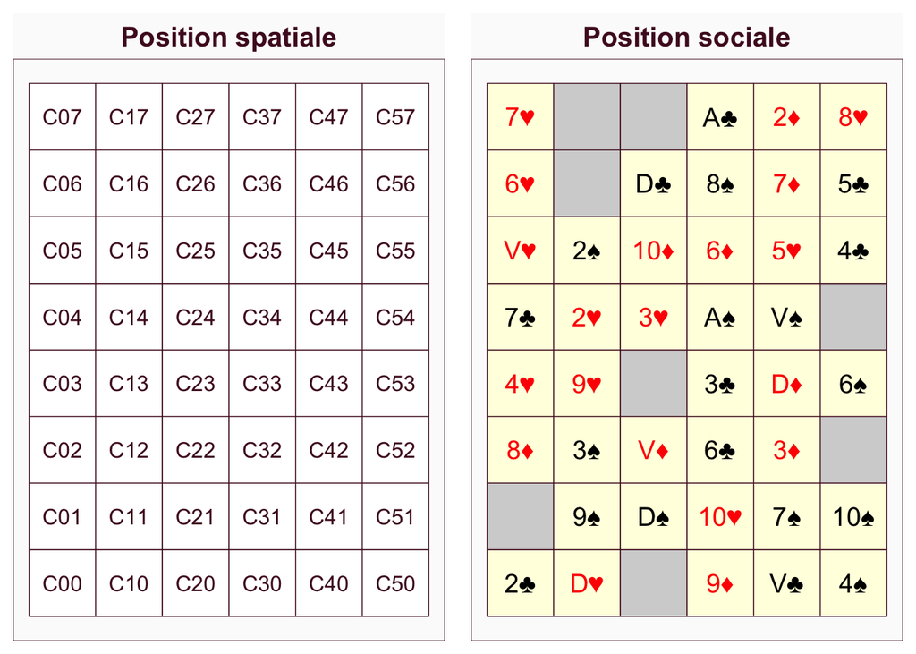

## Le modèle d’Axelrod

### Détermination des voisins

On détermine pour chaque cellule occupée par un individu la liste de ses voisins en notant leur couleur :

```
     i   j Rij  coli  colj
1  C00 C00   0 black black
2  C00 C10   1 black   red
3  C02 C02   0   red   red
4  C02 C03   1   red   red
5  C02 C12   1   red black
6  C03 C02   1   red   red
7  C03 C03   0   red   red
8  C03 C04   1   red black
9  C03 C13   1   red   red
10 C04 C03   1 black   red
```

> **Exemple**: L’individu qui occupe la case C00 est noir et il possède un unique voisin rouge en C10. L’individu qui occupe la case C02 est rouge et il possède un voisin rouge et un voisin noir. L’individu qui occupe la case C03 est rouge avec deux voisins rouges et un voisin noir…

### Règle de changement

On voit donc que dans ce modèle, les individus ont une opinion qui varie en fonction de leur opinion initiale et de celle de leur(s) voisin(s). Ils ont d’autant plus de chances de garder leur opinion qu’ils sont entourés d’individus ayant la même opinion. Et inversement d’autant moins de chance qu’ils sont entourés d’individus ayant des opinions différentes.

### Simulation de la dynamique

> L’exercice est à faire en classe avec les étudiant·es. Mais on peut donner ici un exemple de résultat.

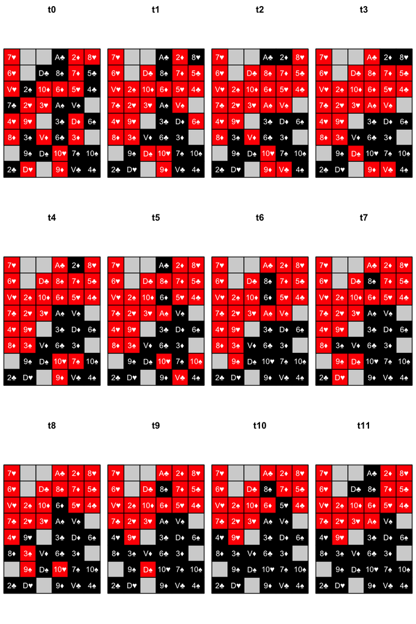

**Commentaire :**

Par rapport à la situation initiale, on évolue rapidement vers une situation de ségrégation entre une région rouge et une région noire. Seule la zone frontière entre les deux régions continue à évoluer un peu et sert d’interface limitée où les deux formes d’opinion sont échangées. Certaines “îles” survivent un certain temps mais elles sont tôt ou tard absorbées et éliminées.

## Le modèle de Schelling

Le modèle de Schelling est assez voisin de celui d’Axelrod dans ses résultats mais il repose sur des hypothèses différentes. En effet, dans le modèle d’Axelrod les individus sont immobiles et ce sont les opinions qui circulent de proche en proche. Au contraire, dans le modèle de Schelling, les individus sont mobiles et se déplacent lorsqu’ils ne sont pas satisfaits des attributs de leurs voisins. Ils vont alors occuper des places vacantes où ils trouveront un voisinage approprié.

Le modèle de Schelling est donc beaucoup plus proche des processus de ségrégation observée dans les espaces urbains et aboutissant à la formation de ghettos et de zones socialement homogènes.

### Règles du modèle de Schelling

En simplifiant à nouveau un peu, on peut résumer ainsi les règles du modèle de Thomas Schelling :

1. Chaque individu est localisé dans une cellule
2. Certaines cellules sont vides
3. Les individus examinent les caractéristiques des individus localisés dans les cellules voisines.
4. Si la proportion de voisins différents est supérieure à un seuil $\alpha$, l’individu se déplace vers une cellule vide où le seuil est respecté.

Supposons que le seuil $\alpha$ soit égal à 0.70, c’est à dire qu’un individu accepte que 70% de ses voisins soient différents de lui. Combien y-a-t-il d’individus mécontents du voisinage dans la configuration suivante en supposant que l’on considère comme voisin uniquement ceux qui ont une frontière commune :

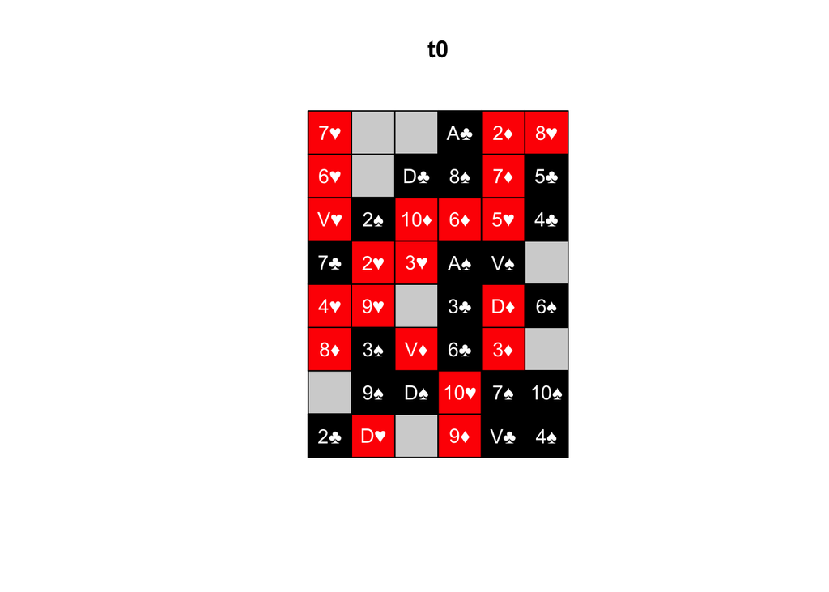

Le problème est que chaque déplacement d’un individu modifie la table de voisinage et remet en cause les calculs. On ne peut donc pas effectuer des changements simultanés comme dans le cas du modèle d’Axelrod. Il faut ici utiliser un modèle asynchrone où les individus insatisfaits se déplacent un par un et où chaque individu recalcule sa situation avant de se déplacer à son tour.

Supposons par exemple que la D♦ effectue un déplacement de C43 en C20 pour rejoindre la case située entre la D♥ et le 9♦ :

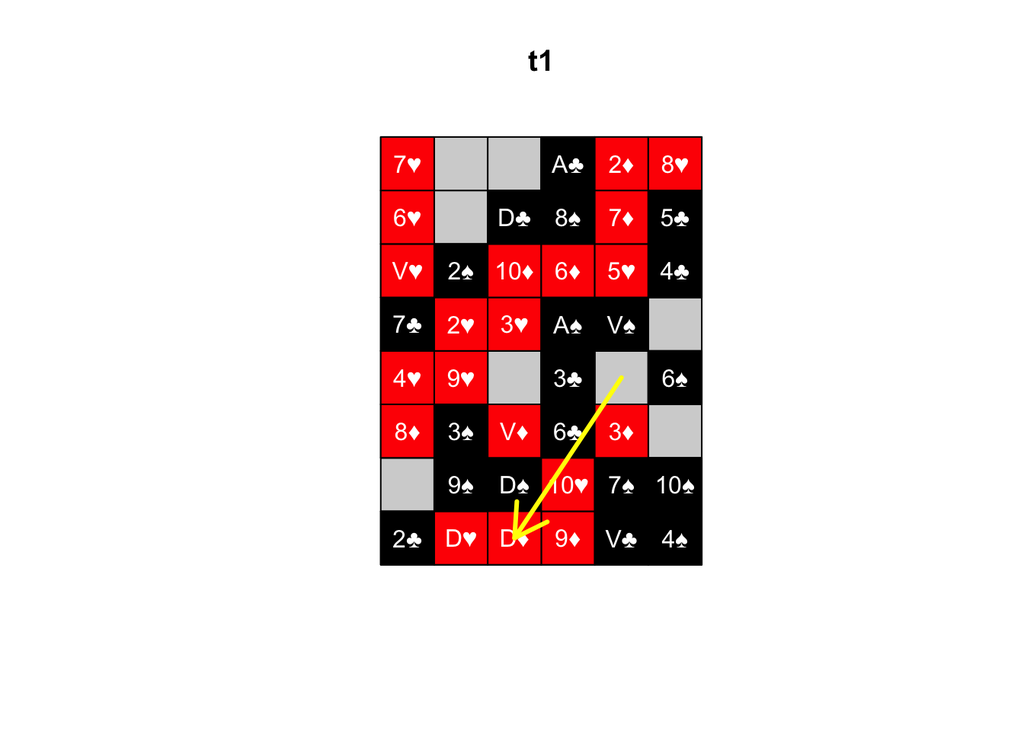

Quelles sont les conséquences pour les individus situés :

- **au point de départ**
  - Le 3♦ qui était satisfait (33% de voisins similaires) a désormais uniquement des voisins noirs et va décider de partir
  - le 6♠ qui était mécontent (100% de voisins différents) ne l’est plus et décide de rester
- **au point d’arrivée**
  - La D♥qui était mécontente (100% de voisins différents) décide de rester
  - la D♠ décide de partir…
  - etc.

Cet exemple simple montre comment les dynamiques de ségrégation sont des systèmes complexes qui engendrent des processus cumulatifs.

### Outils de simulation

De nombreux programmes de simulation existent en ligne pour simuler l’évolution des modèles de Schelling. Voir par exemple [ce site](http://nifty.stanford.edu/2014/mccown-schelling-model-segregation/), du colloque de l’*Association for Computing Machinery’s Special Interest Group on Computer Science Education*.

L’un des résultats principaux de ces modèles de simulation est de montrer qu’il n’est pas besoin d’introduire une forte volonté de ségrégation pour aboutir à des configurations très ségrégées. On s’en rend compte en jouant sur le paramètre $\alpha$.

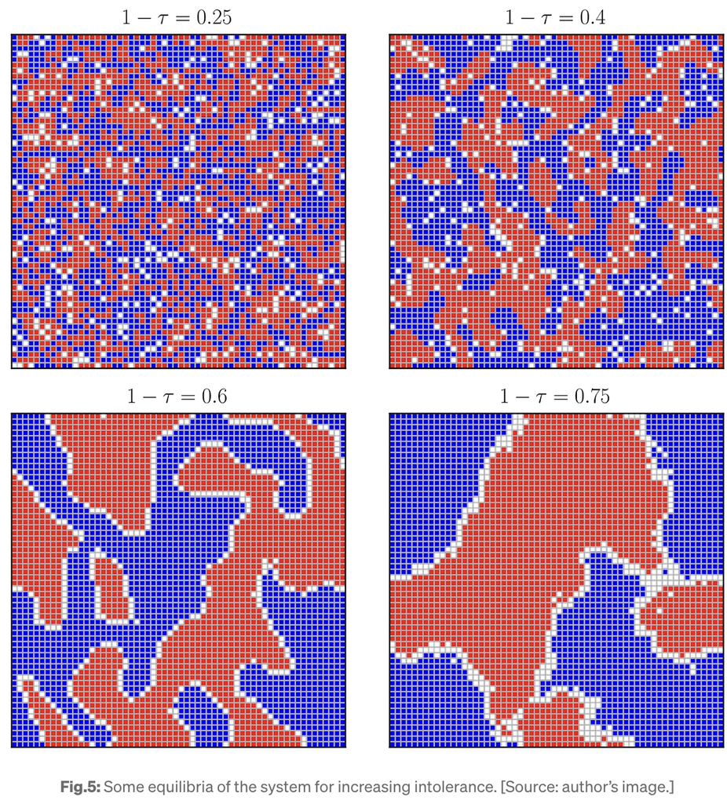

Schelling model

# EXO3 : ACCESSIBILITÉ, POTENTIEL, INTERACTION

## Préparation des données

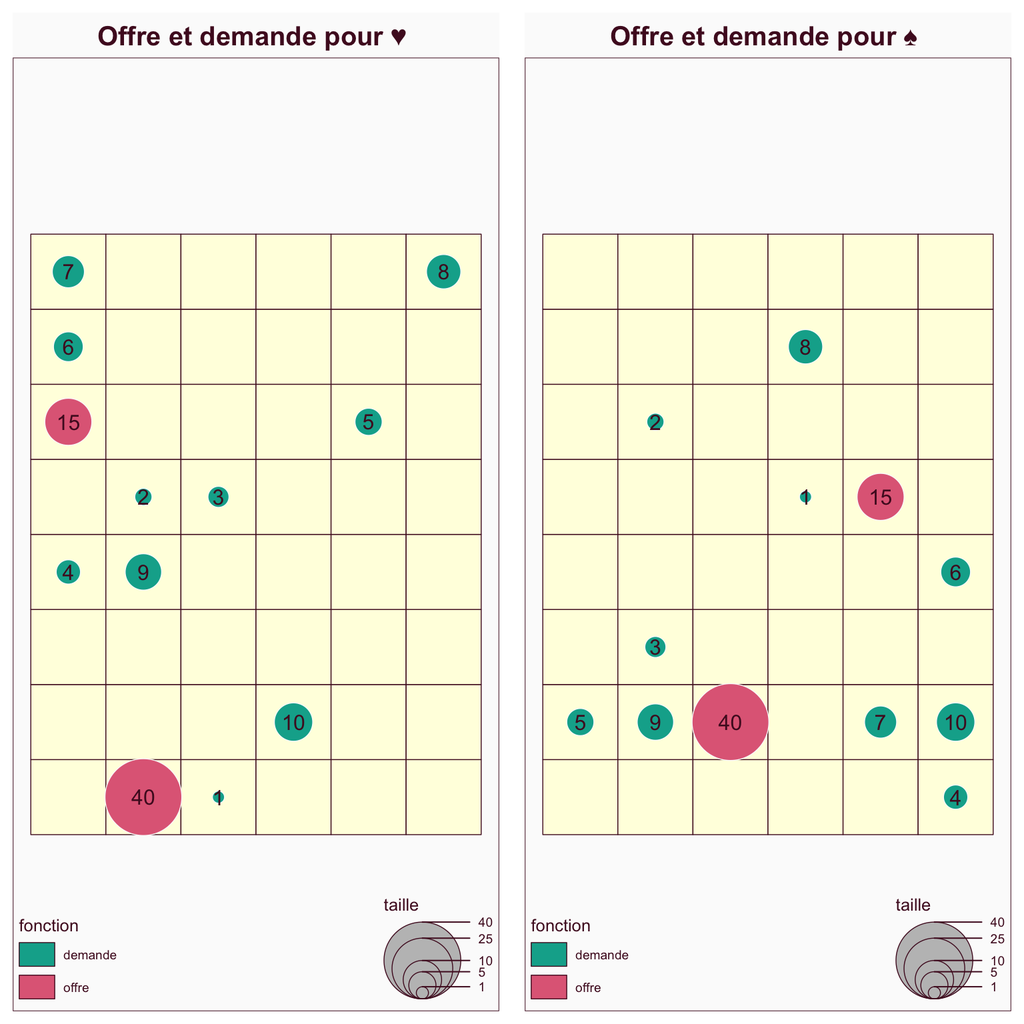

- **Problème 1** : Essayez de répartir au mieux les déplacements des individus vers le service le plus proche tout en respectant les capacités maximales d’accueil des commerces ou des services. Quelle distribution spatiale vous semble la plus intéressante entre “♥” et “♠” ? Justifiez votre réponse.
- **Problème 2** : En supposant qu’il s’agit de **services publics** (e.g. écoles) non soumis aux lois de la concurrence, quelles améliorations pourriez-vous proposer dans chacune des deux situations ? Quel en serait le coût ?
- **Problème 3** : En supposant qu’il s’agit de **commerces ou services privés** (e.g. pharmacies) soumis aux lois de la concurrence, quelles décisions pourraient prendre les acteurs pour augmenter leur part de marché ? Dans quelle mesure ces décisions seraient-elles également profitables aux client·es ?